# Practica 2

# 3 Limpieza de los datos

## 3.1 ¿Los datos contienen ceros o elementos vacíos? ¿Cómo gestionarías cada uno de estos casos?

- Suicides y Suicides/100kpop tienen ceros, pero son valores correctos y no requieren una gestión especial
- HDI.for.year contiene un 70% de vacíos. Es difícil completar con valores fiables, por ello se decide descartarlo.

```r
colSums(is.na(d_suicides))
```

```
##            country               year                sex
##                  0                  0                  0
##                age        suicides_no         population
##                  0                  0                  0
##  suicides.100k.pop   gdp_for_year.... gdp_per_capita....
##                  0                  0                  0
##         generation
##                  0
```

```r
colSums(d_suicides=="")
```

```
##            country               year                sex
##                  0                  0                  0
##                age        suicides_no         population
##                  0                  0                  0
##  suicides.100k.pop   gdp_for_year.... gdp_per_capita....
##                  0                  0                  0
##         generation
##                  0
```

```r
colSums(d_suicides=="0")
```

```
##            country               year                sex
##                  0                  0                  0
##                age        suicides_no         population
##                  0               4281                  0
##  suicides.100k.pop   gdp_for_year.... gdp_per_capita....
##               4281                  0                  0
##         generation
##                  0
```

## 3.2 Identificación y tratamiento de valores extremos.

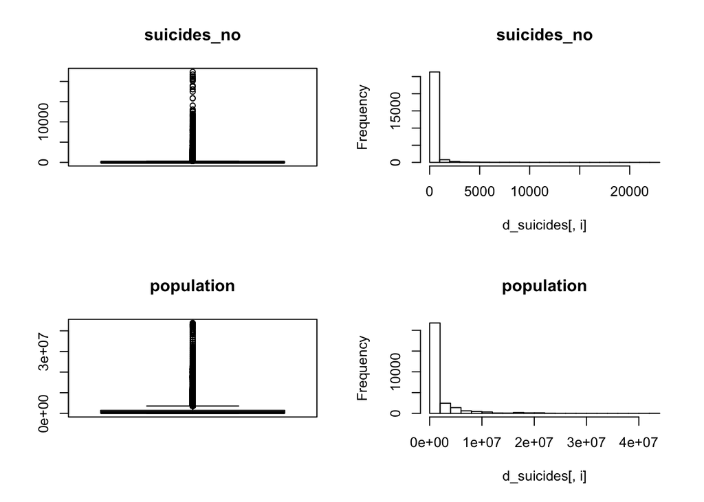

```r
# Análisis mediante diagramas de cajas e histogramas
par(mfrow=c(2,2))
cols <- c("suicides_no","population")
for(i in cols) {
  if (is.integer(d_suicides[,i])){
    boxplot(d_suicides[,i], main = i, width = 100)
    hist(d_suicides[,i], main = i)
  }
}
```

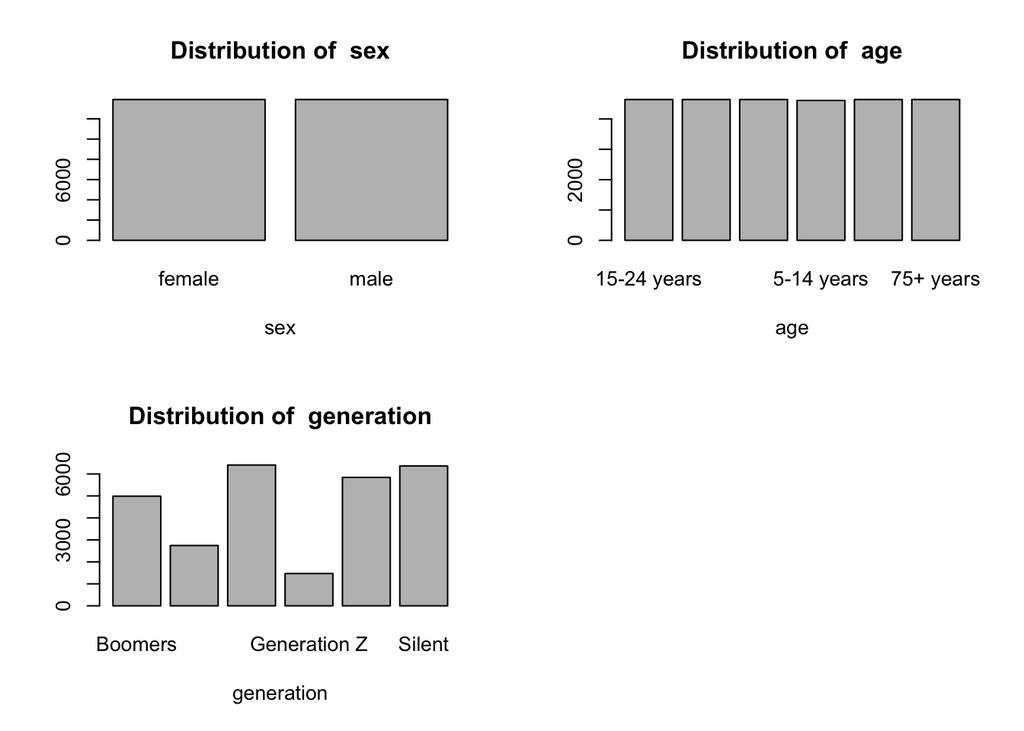

```r
par(mfrow=c(2,2))
cols <- c("sex","age","generation")
for (i in cols){
  if (is.factor(d_suicides[,i])){
    counts <- table(d_suicides[,i])
    barplot(counts,main=paste("Distribution of ", i),
            xlab=i)
  }
}
```

**NOTA:** Por la naturaleza de las variables population y suicides, no siguen una distribución normal.

# 4 Análisis de los datos.

## 4.1 . Selección de los grupos de datos que se quieren analizar/comparar (planificación de los análisis a aplicar).

**CASO 1:** ¿Es mayor la tasa de suicidios en hombres que en mujeres (en función del porcentaje de población)?

- Seleccionamos atributos: sex, suicides_no, population.
- Calculamos la tasa de suicidios por sexo.
- Representamos gráficamente una comparativa entre la tasa de suicidios de hombres y mujeres.

```r
df  <- d_suicides %>% select(sex, suicides_no, population)
df[2:3] <- lapply(df[2:3], as.numeric)
report_case1 <- df %>%
  group_by(sex) %>%
  summarise_all(funs(sum)) %>%
  mutate(suicides_100k_pop = suicides_no / population * 100000)
head(report_case1)
```

```
## # A tibble: 2 x 4
##   sex    suicides_no  population suicides_100k_pop
##   <fct>        <dbl>       <dbl>             <dbl>
## 1 female     1559510 26272781857              5.94
## 2 male       5188910 25049376579             20.7
```

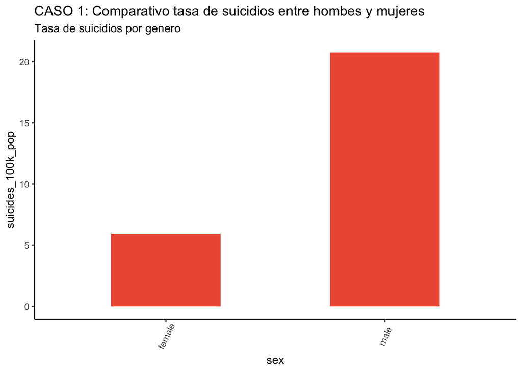

```r
theme_set(theme_classic())
par(mfrow=c(1,1))
g_case1 <- ggplot(report_case1, aes(sex,suicides_100k_pop)) + geom_bar(stat="identity", width = 0.5, fill="tomato2") +
  labs(title="CASO 1: Comparativo tasa de suicidios entre hombes y mujeres",
       subtitle="Tasa de suicidios por genero") +
  theme(axis.text.x = element_text(angle=65, vjust=0.6))

g_case1
```

**CASO 2:** ¿Qué generación tiene mayor tasa de suicidios según el nivel de riqueza de su país en 2008 (crisis económica mundial?

- Clasificamos los países según el producto interior bruto (gdp_per_capita) para el 2008.
- Calculamos la tasa de suicidios por generación / nivel de riqueza.
- Comparamos por generación y tasa de suicidios para el año 2008.
- Empezamos clasificando los países en 3 niveles de riqueza, mediante el algoritmo k-means.
- Se genera la columna nivel_riqueza
- Atributos: suicides_no, population, generation, gdp_per_capita…., country, year

```r
suicides_2008 <- filter(d_suicides, year=='2008')

modelo <- kmeans(suicides_2008$gdp_per_capita...., centers = 3)
modelo
```

```
## K-means clustering with 3 clusters of sizes 564, 240, 216
##
## Cluster means:
##        [,1]
## 1  8756.979
## 2 63554.900
## 3 31222.667
##
## Clustering vector:
##    [1] 1 1 1 1 1 1 1 1 1 1 1 1 1 1 1 1 1 1 1 1 1 1 1 1 1 1 1 1 1 1 1 1 1 1
##   [35] 1 1 1 1 1 1 1 1 1 1 1 1 1 1 3 3 3 3 3 3 3 3 3 3 3 3 2 2 2 2 2 2 2 2
##   [69] 2 2 2 2 2 2 2 2 2 2 2 2 2 2 2 2 3 3 3 3 3 3 3 3 3 3 3 3 3 3 3 3 3 3
##  [103] 3 3 3 3 3 3 1 1 1 1 1 1 1 1 1 1 1 1 1 1 1 1 1 1 1 1 1 1 1 1 2 2 2 2
##  [137] 2 2 2 2 2 2 2 2 1 1 1 1 1 1 1 1 1 1 1 1 1 1 1 1 1 1 1 1 1 1 1 1 1 1
##  [171] 1 1 1 1 1 1 1 1 1 1 2 2 2 2 2 2 2 2 2 2 2 2 1 1 1 1 1 1 1 1 1 1 1 1
```

[output cut: 34 more lines]

```r
modelo$cluster
```

[output not shown]

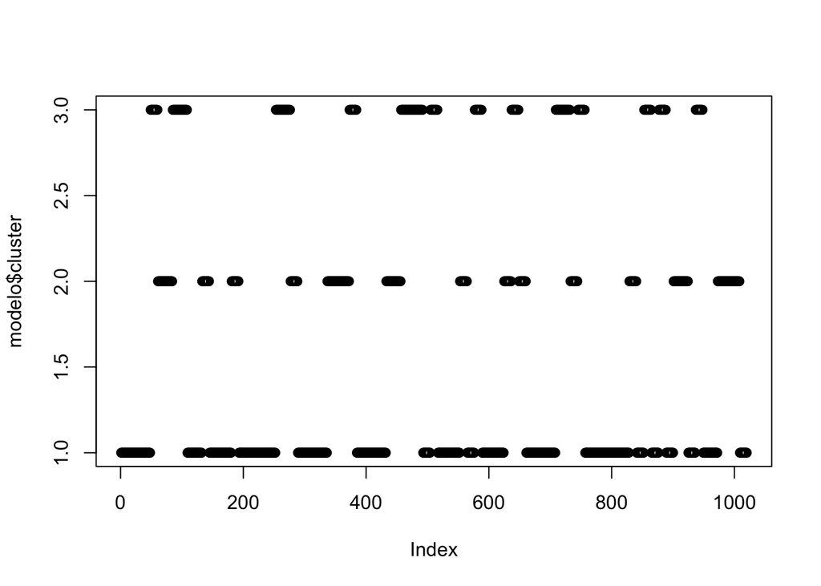

```r
par(mfrow=c(1,1))
plot(modelo$cluster)
```

```r
suicides_2008$nivel_riqueza <- modelo$cluster
head(suicides_2008)
```

```
##   country year    sex         age suicides_no population suicides.100k.pop
## 1 Albania 2008   male 25-34 years          21     172855             12.15
## 2 Albania 2008   male 35-54 years          37     377119              9.81
## 3 Albania 2008   male 55-74 years          21     228672              9.18
## 4 Albania 2008 female   75+ years           5      59369              8.42
## 5 Albania 2008 female 15-24 years          20     276073              7.24
## 6 Albania 2008 female 25-34 years           9     182663              4.93
##   gdp_for_year.... gdp_per_capita....   generation nivel_riqueza
## 1   12,881,352,688               4672 Generation X             1
## 2   12,881,352,688               4672      Boomers             1
## 3   12,881,352,688               4672       Silent             1
## 4   12,881,352,688               4672       Silent             1
## 5   12,881,352,688               4672   Millenials             1
## 6   12,881,352,688               4672 Generation X             1
```

```r
report_case2 <- tibble()

for (idx in (1:3)) {
  suicides_2008_riqueza <- filter(suicides_2008, nivel_riqueza==idx)
  df  <- suicides_2008_riqueza %>% select(generation, suicides_no, population)

  df[2:3] <- lapply(df[2:3], as.numeric)
  report <- df %>%
    group_by(generation) %>%
    summarise_all(funs(sum)) %>%
    mutate(suicides_100k_pop = suicides_no / population * 100000) %>%
    mutate(nivel_riqueza= paste("Nivel ", idx))

  print(paste("Nivel de Riqueza ", idx))
  print(report)
  report_case2 <- rbind(report_case2, report)
}
```

```
## [1] "Nivel de Riqueza  1"
## # A tibble: 5 x 5
##   generation   suicides_no population suicides_100k_pop nivel_riqueza
##   <fct>              <dbl>      <dbl>             <dbl> <chr>
## 1 Boomers            37105  257826158            14.4   Nivel  1
## 2 Generation X       20265  162811966            12.4   Nivel  1
## 3 Generation Z        1157  164409470             0.704 Nivel  1
## 4 Millenials         16961  176561452             9.61  Nivel  1
## 5 Silent             28427  168182913            16.9   Nivel  1
## [1] "Nivel de Riqueza  2"
## # A tibble: 5 x 5
##   generation   suicides_no population suicides_100k_pop nivel_riqueza
##   <fct>              <dbl>      <dbl>             <dbl> <chr>
## 1 Boomers            31020  187473409            16.5   Nivel  2
## 2 Generation X       10123   85564331            11.8   Nivel  2
## 3 Generation Z         348   79847095             0.436 Nivel  2
## 4 Millenials          7475   87389270             8.55  Nivel  2
## 5 Silent             27550  168891823            16.3   Nivel  2
## [1] "Nivel de Riqueza  3"
## # A tibble: 5 x 5
##   generation   suicides_no population suicides_100k_pop nivel_riqueza
##   <fct>              <dbl>      <dbl>             <dbl> <chr>
## 1 Boomers            18539   97489717            19.0   Nivel  3
## 2 Generation X        7368   49155706            15.0   Nivel  3
## 3 Generation Z         135   34647331             0.390 Nivel  3
## 4 Millenials          3709   38250159             9.70  Nivel  3
## 5 Silent             25265  102120051            24.7   Nivel  3
```

```r
head(report_case2)
```

```
## # A tibble: 6 x 5
##   generation   suicides_no population suicides_100k_pop nivel_riqueza
##   <fct>              <dbl>      <dbl>             <dbl> <chr>
## 1 Boomers            37105  257826158            14.4   Nivel  1
## 2 Generation X       20265  162811966            12.4   Nivel  1
## 3 Generation Z        1157  164409470             0.704 Nivel  1
## 4 Millenials         16961  176561452             9.61  Nivel  1
## 5 Silent             28427  168182913            16.9   Nivel  1
## 6 Boomers            31020  187473409            16.5   Nivel  2
```

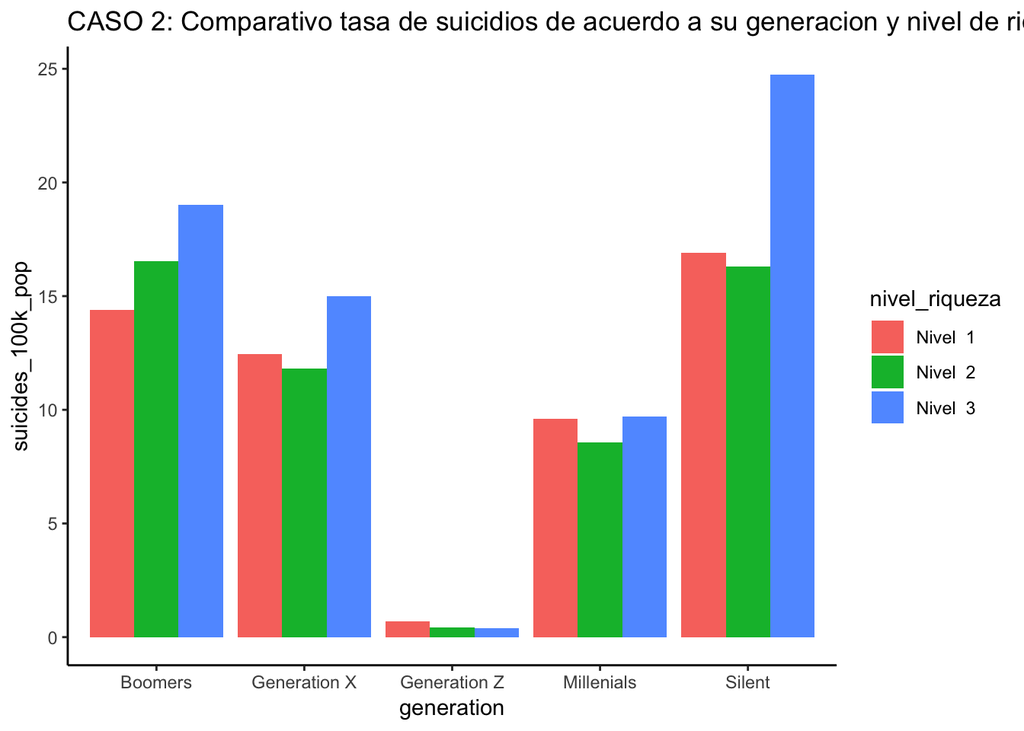

```r
g_case2 <- ggplot(report_case2, aes(fill=nivel_riqueza,y=suicides_100k_pop,x=generation)) + geom_bar(position="dodge", stat="identity") +
  labs(title="CASO 2: Comparativo tasa de suicidios de acuerdo a su generacion y nivel de riqueza")
g_case2
```

**CASO 3:** ¿Cómo ha evolucionado la tasa de suicidios desde 1985 en España?

- Atributos: suicides_no, population, year, country=Spain
- Creamos una columna que sume el número de suicidios por año (para cada año existen 12 registros, 2 sex x 6 age).
- Creamos una columna que sume la población por año.
- Calculamos la tasa de suicidios por año.
- Graficamos para identificar picos o valores altos.

```r
suicides_spain <- select(data, country, year, suicides_no, population)
suicides_spain <- filter(d_suicides, country=='Spain')
df  <- suicides_spain %>% select(year, suicides_no, population)
df[2:3] <- lapply(df[2:3], as.numeric)
report_case3 <- df %>%
  group_by(year) %>%
  summarise_all(funs(sum)) %>%
  mutate(suicides_100k_pop = suicides_no / population * 100000)
head(report_case3)
```

```
## # A tibble: 6 x 4
##    year suicides_no population suicides_100k_pop
##   <int>       <dbl>      <dbl>             <dbl>
## 1  1985        2514   35997000              6.98
## 2  1986        2755   36223000              7.61
## 3  1987        2804   36425700              7.70
## 4  1988        2960   36597300              8.09
## 5  1989        2987   36740400              8.13
## 6  1990        2939   36861400              7.97
```

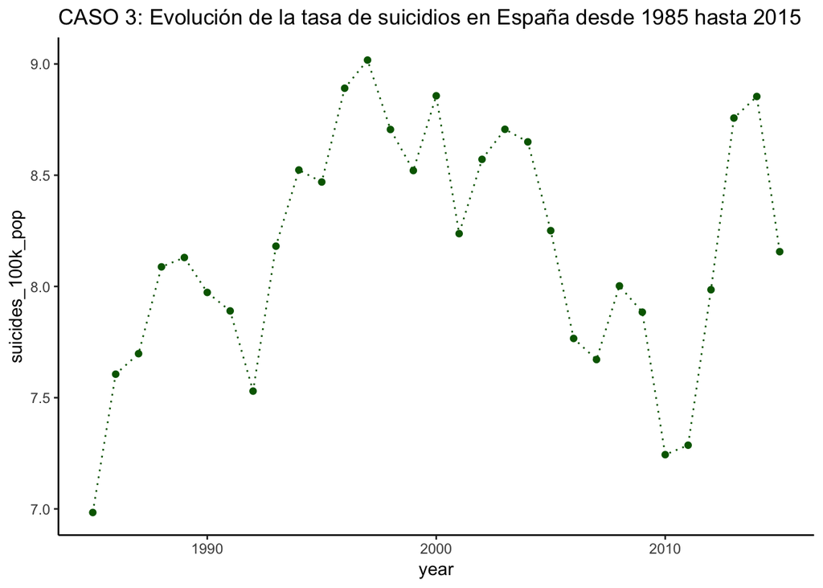

```r
par(mfrow=c(1,1))
g_case3 <- ggplot(report_case3, aes(x=year,y=suicides_100k_pop)) + geom_line(stat="identity", color="darkgreen", linetype="dotted") +
  labs(title="CASO 3: Evolución de la tasa de suicidios en España desde 1985 hasta 2015") +
  geom_point(color="darkgreen")
g_case3
```

## 4.2 Comprobación de la normalidad y homogeneidad de la varianza.

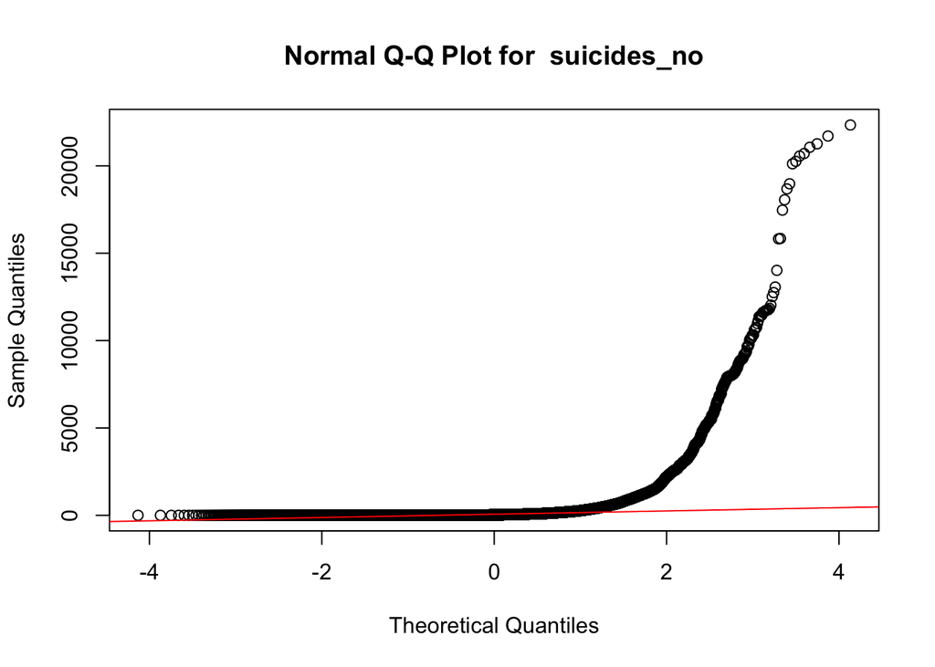

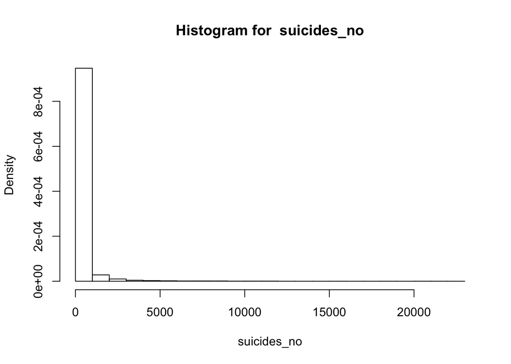

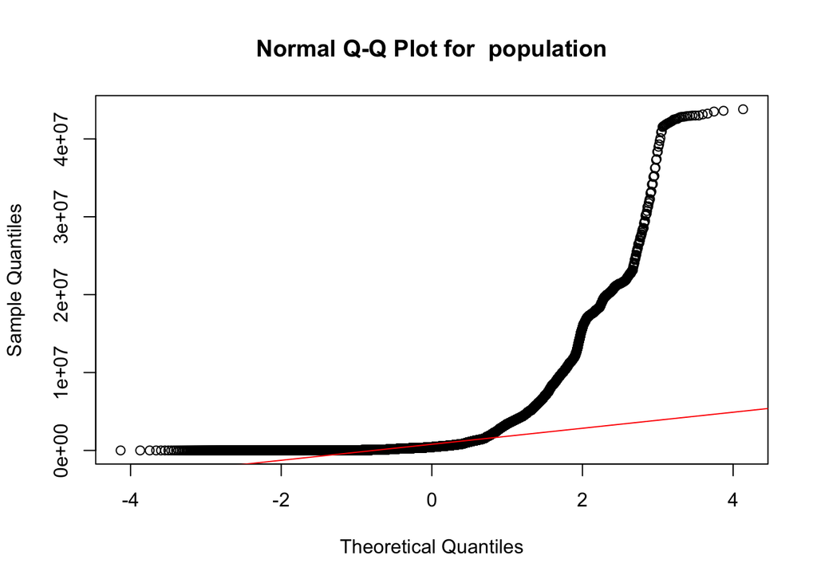

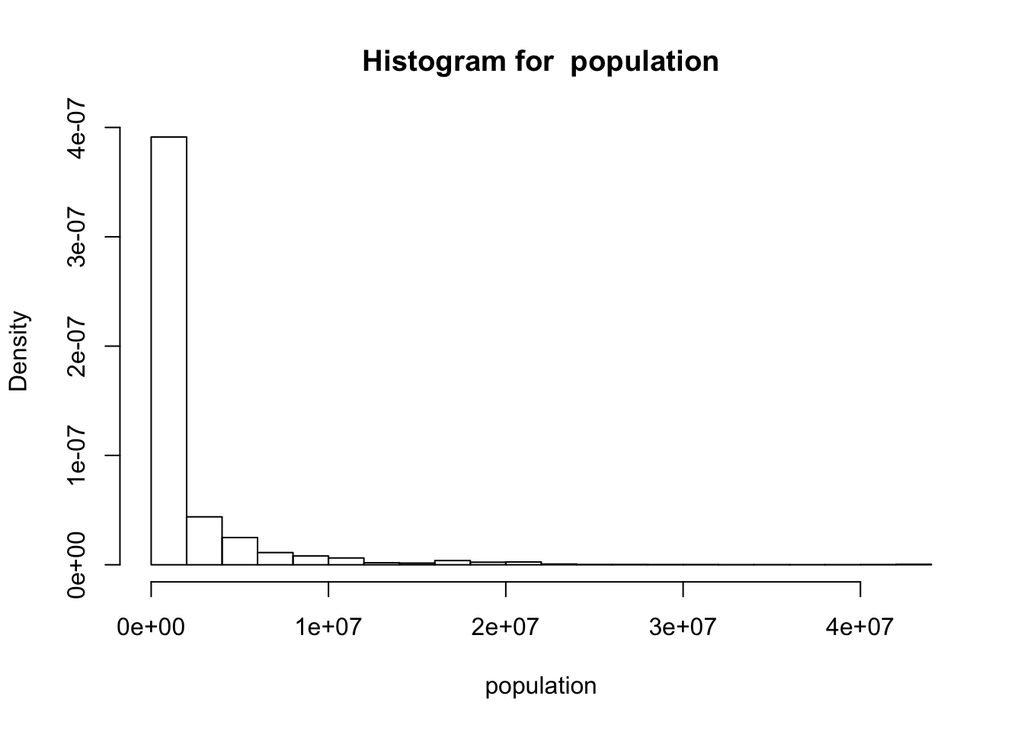

```r
# Análisis de normalidad

par(mfrow=c(1,1))
cols <- c("suicides_no", "population")
for (i in cols){
  qqnorm(d_suicides[,i],main = paste("Normal Q-Q Plot for ", i))
  qqline(d_suicides[,i],col="red")
  hist(d_suicides[,i],
       main=paste("Histogram for ", i),
       xlab=i, freq = FALSE)
}
```

**CONCLUSIONES:**

- Se concluye que no son variables normales.
- Análisis de homogeneidad de la varianza: no aplica.

# 5 Representación de los resultados a partir de tablas y gráficas.

```r
par(mfrow=c(2,2))
report_case1
```

```
## # A tibble: 2 x 4
##   sex    suicides_no  population suicides_100k_pop
##   <fct>        <dbl>       <dbl>             <dbl>
## 1 female     1559510 26272781857              5.94
## 2 male       5188910 25049376579             20.7
```

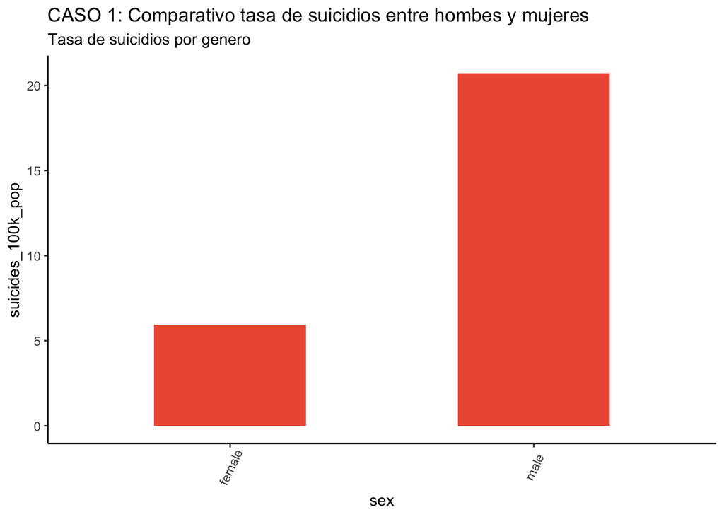

```r
g_case1
```

```r
report_case2
```

```
## # A tibble: 15 x 5
##    generation   suicides_no population suicides_100k_pop nivel_riqueza
##    <fct>              <dbl>      <dbl>             <dbl> <chr>
##  1 Boomers            37105  257826158            14.4   Nivel  1
##  2 Generation X       20265  162811966            12.4   Nivel  1
##  3 Generation Z        1157  164409470             0.704 Nivel  1
##  4 Millenials         16961  176561452             9.61  Nivel  1
##  5 Silent             28427  168182913            16.9   Nivel  1
##  6 Boomers            31020  187473409            16.5   Nivel  2
##  7 Generation X       10123   85564331            11.8   Nivel  2
##  8 Generation Z         348   79847095             0.436 Nivel  2
##  9 Millenials          7475   87389270             8.55  Nivel  2
## 10 Silent             27550  168891823            16.3   Nivel  2
## 11 Boomers            18539   97489717            19.0   Nivel  3
## 12 Generation X        7368   49155706            15.0   Nivel  3
## 13 Generation Z         135   34647331             0.390 Nivel  3
## 14 Millenials          3709   38250159             9.70  Nivel  3
## 15 Silent             25265  102120051            24.7   Nivel  3
```

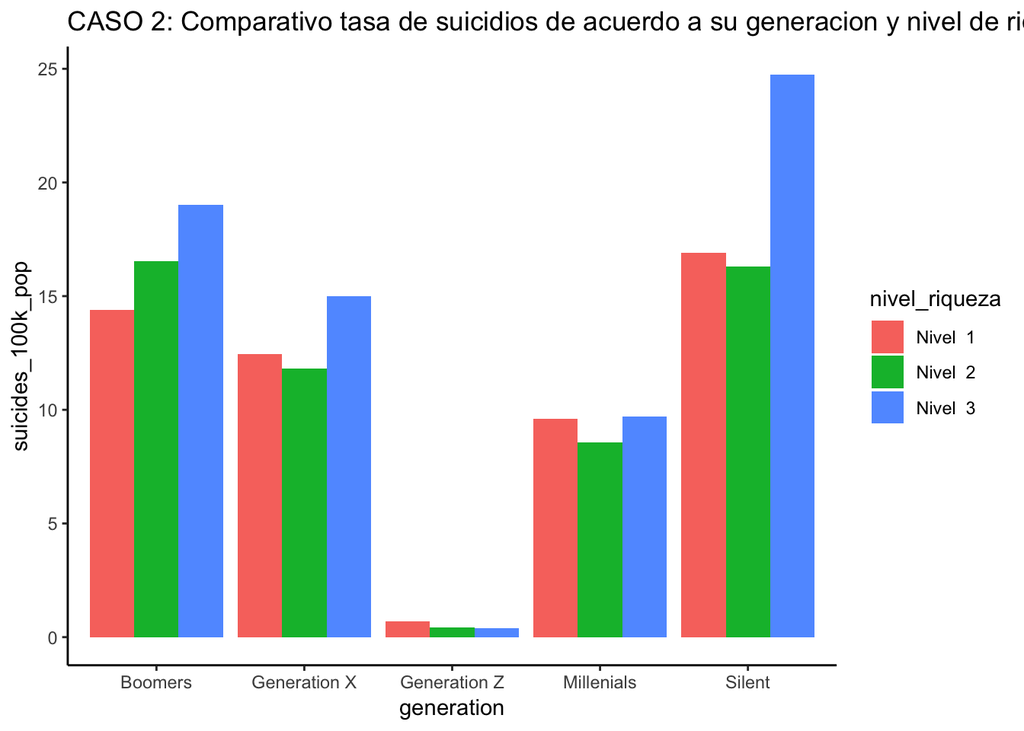

```r
g_case2
```

```r
report_case3
```

```
## # A tibble: 31 x 4
##     year suicides_no population suicides_100k_pop
##    <int>       <dbl>      <dbl>             <dbl>
##  1  1985        2514   35997000              6.98
##  2  1986        2755   36223000              7.61
##  3  1987        2804   36425700              7.70
##  4  1988        2960   36597300              8.09
##  5  1989        2987   36740400              8.13
##  6  1990        2939   36861400              7.97
##  7  1991        2916   36958100              7.89
##  8  1992        2786   37000900              7.53
##  9  1993        3037   37122100              8.18
## 10  1994        3171   37203100              8.52
## # … with 21 more rows
```

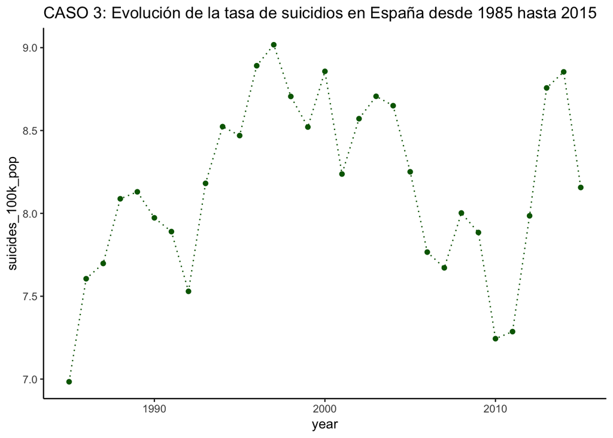

```r
g_case3
```

# 6 Resolución del problema. A partir de los resultados obtenidos, ¿cuáles son las conclusiones? ¿Los resultados permiten responder al problema?

**CASO 1: Tasa de suicidios en hombres y en mujeres**

La conclusión aquí es simple: el suicidio afecta sensiblemente más a los hombres, ya que la tasa es más del triple que en las mujeres.

**CASO 2: Tasa de suicidios por generaciones y nivel de riqueza**

La primera conclusión obvia es que para todas las generaciones salvo una la mayor tasa de suicidios se da entre los países del segundo mundo. El análisis que se puede hacer de esto es que en los países más ricos la crisis no ha golpeado tan fuerte o ha habido más medios para resistir, mientras que en los países más pobres, cuyo nivel de vida previo ya era bajo, la crisis económica posiblemente no supone un gran cambio.

Por otra parte, donde existe una mayor desigualdad es en la generación Silent (nacidos entre finales de los años 20 y mediados de los 40), en la cual destaca claramente el segundo mundo, además de ser la generación más impactada respecto a las demás. En cuanto a lo segundo, se puede concluir que al ser una generación mayor, tiene menor población y por lo tanto la tasa aumenta con facilidad.

**Más conclusiones:** En la generación Z (nacidos de mediados de los 90 a mediados de los 2000) es en la que claramente se observan menores tasas. Hay que considerar que durante más de la mitad del periodo estudiado no han podido nacer personas de esa generación o bien han sido muy pequeñas como para cometer suicidio, por lo cual es lógico el resultado. Además, es destacable que es el único grupo de población en el que el tercer mundo tiene una tasa más alta. Esto da que pensar que posiblemente los niños del tercer mundo afrontan dificultades que les llevan a cometer suicidios antes que en países más avanzados.

Finalmente se puede observar que las tasas de suicidio han ido disminuyendo por generaciones (en orden cronológico: silent, boomers, x, millenials, z). Siendo un poco optimistas podemos pensar que el mundo ha ido mejorando. Además, las nuevas generaciones han sufrido menor impacto de las guerras y sus consecuencias.

**CASO 3: Evolución de la tasa de suicidios en España y su relación con las crisis económicas**

# 7 Código: Hay que adjuntar el código, preferiblemente en R, con el que se ha realizado la limpieza, análisis y representación de los datos

[acceder código fuente](https://github.com/gabrielpaladines/uoc-practica2)

# 8 OTROS

```r
write.csv(d_suicides, file="suicides_datos_finales.csv")
```

# 9 Contribuciones

| Contribuciones | Firma |
| --- | --- |
| Investigación previa | Jaime Pardo, Gabriel Paladines |
| Redacción de respuestas | Jaime Pardo, Gabriel Paladines |
| Desarrollo código | Jaime Pardo, Gabriel Paladines |